# Part II - (Loan outcome dependencies for Prosper loan data)

## by (Olorunleke Akindote-White)

## Investigation Overview

> This presentation is aimed at revealing the influence of such factors as employment status, income range and borrower rate on the loan outcome. The first two factors are presented using a heat map while the third is presented using a boxplot.

## Dataset Overview

> This data set contains 113,937 loans with 81 variables on each loan, including loan amount, borrower rate (or interest rate), current loan status, borrower income, and many others.

## (Loan status vs Employment status)

> This heatmap shows the interaction between Employment status and loan status and we see that employed individuals interact the most with loans given the color indication and count of profiles in the Employed and Full-time categories for current and completed loans.

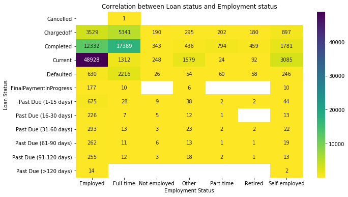

## (Loan status vs income range)

> This heatmap shows the interaction between income range and loan status and we see that there is an increase in number of current loans across the heatmap from left to right and a drop off after the 75,000 USD mark. The trend is similar for completed loans up until the 50,000 USD mark after which there is a drop off.

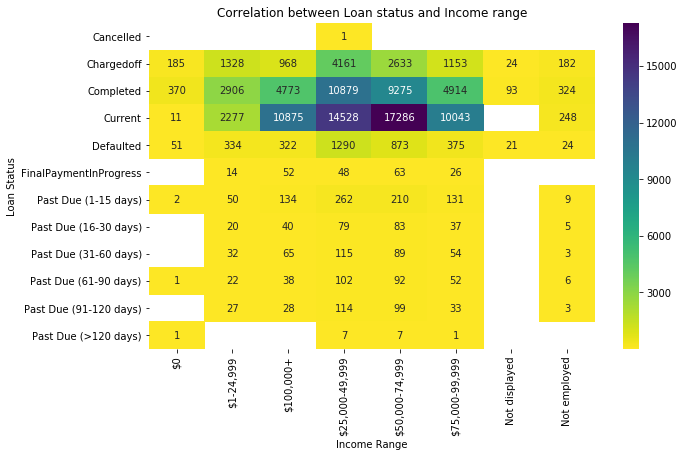

## (Loan status vs borrower rate)

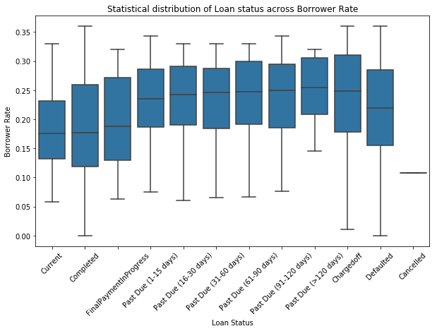